# Model Comparison

Harrison Cradduck, Nick Berry

2025-11-07

# 1 Data Loading

## 1.1 Trees

Read in the RDS files for the best decision tree, Random Forest, and XGBoost models.

```r
# read in .rds for best decision tree
best_tree <- read_rds("../part2_files/dummy_best_tree.rds")

# read in .rds for best random forest model
best_rf <- read_rds("../part2_files/random_forest_dmy.rds")

# read in .rds for best XGBoost model
best_xgb <- read_rds("../part2_files/XGBoost_dmy.rds")
```

## 1.2 Holdout Data Set

Read in the holdout data sets used for each model.

### 1.2.1 Decision Tree

```r
# read in .csv training data file
data_train <- readRDS("../data/final_cleaned_train_part2.rds")

# read in .csv holdout data file
data_holdout <- readRDS("../data/final_cleaned_holdout_part2.rds")

# set response variable
response <- "loan_default"

# set predictor variables
predictor_cols <- setdiff(names(data_train), response)

# create dummy variables for all factor columns in data_train
data_train_tree <- fastDummies::dummy_cols(
  data_train[, predictor_cols],
  remove_first_dummy = FALSE,
  remove_selected_columns = TRUE
)
data_train_tree[[response]] <- data_train[[response]]

colnames(data_train_tree) <- make.names(colnames(data_train_tree))

# create dummy variables for all factor columns in data_holdout
data_holdout_tree <- fastDummies::dummy_cols(
  data_holdout[, predictor_cols],
  remove_first_dummy = FALSE,
  remove_selected_columns = TRUE
)
data_holdout_tree[[response]] <- data_holdout[[response]]

colnames(data_holdout_tree) <- make.names(colnames(data_train_tree))
```

### 1.2.2 RF and XGB Models

```r
# read in .rds holdout predictions file
holdout_predictions <- readRDS("../part2_files/holdout_predictions.rds")
```

# 2 Model Predictions and Metrics

## 2.1 Decision Tree

```r
# predict probabilities on holdout
best_tree_pred_prob <- predict(best_tree, data_holdout_tree, type = "prob")[, "Yes"]

# create true labels (1 = Yes, 0 = No)
true_labels <- ifelse(data_holdout_tree$loan_default == "Yes", 1, 0)

# use ROCR to evaluate across thresholds
pred <- ROCR::prediction(best_tree_pred_prob, true_labels)

# get precision-recall performance
perf <- ROCR::performance(pred, measure = "prec", x.measure = "rec")

# compute AUC
perf_auc <- ROCR::performance(pred, measure = "auc")
auc_tree <- perf_auc@y.values[[1]]
print(auc_tree)
```

```
## [1] 0.8039038
```

```r
# extract values
precision <- perf@y.values[[1]]
recall <- perf@x.values[[1]]
thresholds <- perf@alpha.values[[1]]

# compute F1
f1 <- 2 * (precision * recall) / (precision + recall)
f1[is.nan(f1)] <- 0

# find best threshold and F1
best_index_tree <- which.max(f1)
best_thresh_tree <- thresholds[best_index_tree]
best_f1_tree <- f1[best_index_tree]

# print results
cat("Best threshold:", best_thresh_tree, "\n")
```

```
## Best threshold: 0.3047104
```

```r
cat("Best F1 score:", best_f1_tree, "\n")
```

```
## Best F1 score: 0.5666049
```

```r
# create final class predictions using best threshold
best_tree_pred_class <- factor(
  ifelse(best_tree_pred_prob >= best_thresh_tree, "Yes", "No"),
  levels = c("No", "Yes")
)

# confusion matrix with optimal threshold
cm <- caret::confusionMatrix(best_tree_pred_class, data_holdout_tree$loan_default, positive = "Yes")
print(cm)
```

```
## Confusion Matrix and Statistics
##
##           Reference
## Prediction    No   Yes
##        No  54068  5602
##        Yes  9595  9934
##
##                Accuracy : 0.8081
##                  95% CI : (0.8054, 0.8109)
##     No Information Rate : 0.8038
##     P-Value [Acc > NIR] : 0.001197
##
##                   Kappa : 0.4454
##
##  Mcnemar's Test P-Value : < 2.2e-16
##
##             Sensitivity : 0.6394
##             Specificity : 0.8493
##          Pos Pred Value : 0.5087
##          Neg Pred Value : 0.9061
##              Prevalence : 0.1962
##          Detection Rate : 0.1254
##    Detection Prevalence : 0.2466
##       Balanced Accuracy : 0.7444
##
##        'Positive' Class : Yes
##
```

```r
# predict probabilities on holdout
best_rf_pred_prob <- holdout_predictions$rf_cv_dmy_prob

# create true labels (1 = Yes, 0 = No)
true_labels <- holdout_predictions$loan_default

# use ROCR to evaluate across thresholds
pred <- ROCR::prediction(best_rf_pred_prob, true_labels)

# get precision-recall performance
perf <- ROCR::performance(pred, measure = "prec", x.measure = "rec")

# compute AUC
perf_auc <- ROCR::performance(pred, measure = "auc")
auc_rf <- perf_auc@y.values[[1]]
print(auc_rf)
```

```
## [1] 0.8508873
```

```r
# extract values
precision <- perf@y.values[[1]]
recall <- perf@x.values[[1]]
thresholds <- perf@alpha.values[[1]]

# compute F1
f1 <- 2 * (precision * recall) / (precision + recall)
f1[is.nan(f1)] <- 0

# find best threshold and F1
best_index_rf <- which.max(f1)
best_thresh_rf <- thresholds[best_index_rf]
best_f1_rf <- f1[best_index_rf]

# print results
cat("Best threshold:", best_thresh_rf, "\n")
```

```
## Best threshold: 0.62
```

```r
cat("Best F1 score:", best_f1_rf, "\n")
```

```
## Best F1 score: 0.5935158
```

```r
# create final class predictions using best threshold
best_rf_pred_class <- factor(
  ifelse(best_rf_pred_prob >= best_thresh_rf, "Yes", "No"),
  levels = c("No", "Yes")
)

# confusion matrix with optimal threshold
cm <- caret::confusionMatrix(best_rf_pred_class, holdout_predictions$loan_default, positive = "Yes")
print(cm)
```

```
## Confusion Matrix and Statistics
##
##           Reference
## Prediction    No   Yes
##        No  54146  4964
##        Yes  9517 10572
##
##                Accuracy : 0.8172
##                  95% CI : (0.8144, 0.8198)
##     No Information Rate : 0.8038
##     P-Value [Acc > NIR] : < 2.2e-16
##
##                   Kappa : 0.478
##
##  Mcnemar's Test P-Value : < 2.2e-16
##
##             Sensitivity : 0.6805
##             Specificity : 0.8505
##          Pos Pred Value : 0.5263
##          Neg Pred Value : 0.9160
##              Prevalence : 0.1962
##          Detection Rate : 0.1335
##    Detection Prevalence : 0.2537
##       Balanced Accuracy : 0.7655
##
##        'Positive' Class : Yes
##
```

```r
# predict probabilities on holdout
best_xgb_pred_prob <- holdout_predictions$xgb_dmy_prob

# create true labels (1 = Yes, 0 = No)
true_labels <- holdout_predictions$loan_default

# use ROCR to evaluate across thresholds
pred <- ROCR::prediction(best_xgb_pred_prob, true_labels)

# get precision-recall performance
perf <- ROCR::performance(pred, measure = "prec", x.measure = "rec")

# compute AUC
perf_auc <- ROCR::performance(pred, measure = "auc")
auc_xgb <- perf_auc@y.values[[1]]
print(auc_xgb)
```

```
## [1] 0.8562651
```

```r
# extract values
precision <- perf@y.values[[1]]
recall <- perf@x.values[[1]]
thresholds <- perf@alpha.values[[1]]

# compute F1
f1 <- 2 * (precision * recall) / (precision + recall)
f1[is.nan(f1)] <- 0

# find best threshold and F1
best_index_xgb <- which.max(f1)
best_thresh_xgb <- thresholds[best_index_xgb]
best_f1_xgb <- f1[best_index_xgb]

# print results
cat("Best threshold:", best_thresh_xgb, "\n")
```

```
## Best threshold: 0.6436434
```

```r
cat("Best F1 score:", best_f1_xgb, "\n")
```

```
## Best F1 score: 0.5992124
```

```r
# create final class predictions using best threshold
best_xgb_pred_class <- factor(
  ifelse(best_xgb_pred_prob >= best_thresh_xgb, "Yes", "No"),
  levels = c("No", "Yes")
)

# confusion matrix with optimal threshold
cm <- caret::confusionMatrix(best_xgb_pred_class, holdout_predictions$loan_default, positive = "Yes")
print(cm)
```

```
## Confusion Matrix and Statistics
##
##           Reference
## Prediction    No   Yes
##        No  54833  5113
##        Yes  8830 10423
##
##                Accuracy : 0.8239
##                  95% CI : (0.8213, 0.8266)
##     No Information Rate : 0.8038
##     P-Value [Acc > NIR] : < 2.2e-16
##
##                   Kappa : 0.4881
##
##  Mcnemar's Test P-Value : < 2.2e-16
##
##             Sensitivity : 0.6709
##             Specificity : 0.8613
##          Pos Pred Value : 0.5414
##          Neg Pred Value : 0.9147
##              Prevalence : 0.1962
##          Detection Rate : 0.1316
##    Detection Prevalence : 0.2431
##       Balanced Accuracy : 0.7661
##
##        'Positive' Class : Yes
##
```

# 3 Model Comparison

```r
# compare models
comparison <- data.frame(
  Model = c("Best Tree", "Best Random Forest", "Best XGBoost"),
  AUC = c(auc_tree, auc_rf, auc_xgb),
  Best_Threshold = c(best_thresh_tree, best_thresh_rf, best_thresh_xgb),
  Best_F1 = c(best_f1_tree, best_f1_rf, best_f1_xgb)
)
comparison <- comparison[order(-comparison$Best_F1), ]
print(comparison)
```

```
##                Model       AUC Best_Threshold   Best_F1
## 3       Best XGBoost 0.8562651      0.6436434 0.5992124
## 2 Best Random Forest 0.8508873      0.6200000 0.5935158
## 1          Best Tree 0.8039038      0.3047104 0.5666049
```

**The model comparison above shows that the best XGBoost model results in the highest F1 score, while the best Random Forest results in the second highest F1 score. All three models result in very similar F1 scores but vary in thresholds.**

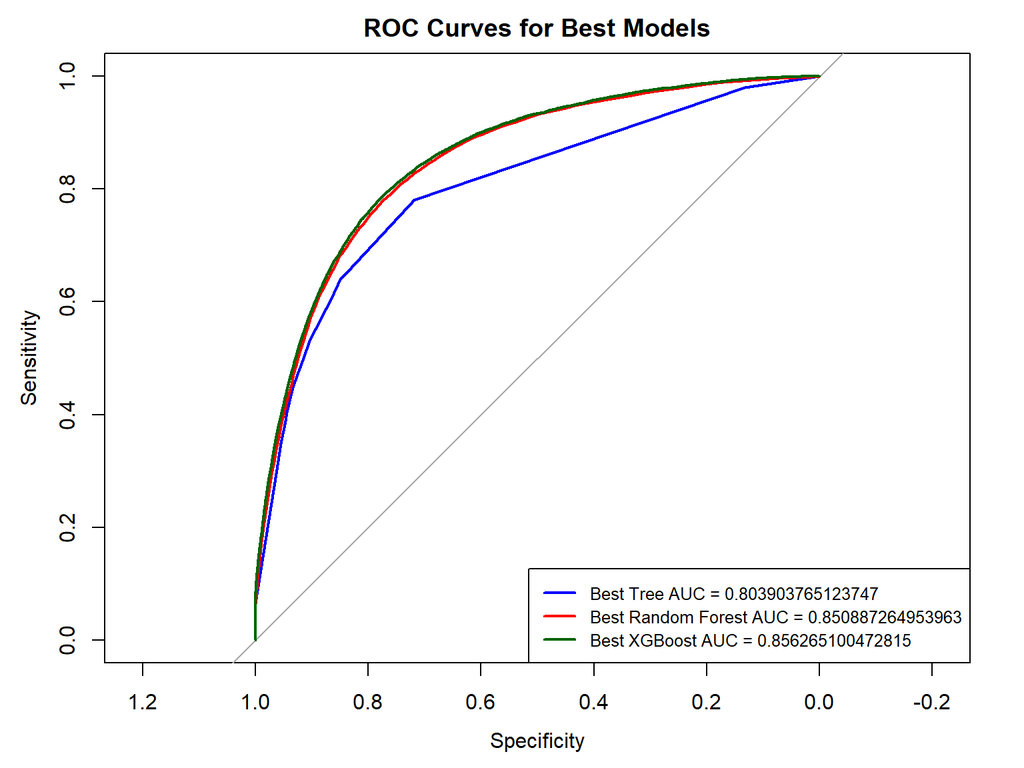

```r
# compare models by plotting ROC curves
roc_tree <- pROC::roc(data_holdout_tree$loan_default, predict(best_tree, data_holdout_tree, type = "prob")[, "Yes"])
roc_rf <- pROC::roc(holdout_predictions$loan_default, best_rf_pred_prob)
roc_xgb <- pROC::roc(holdout_predictions$loan_default, best_xgb_pred_prob)

plot(roc_tree, col = "blue", lwd = 2, main = "ROC Curves for Best Models")
plot(roc_rf, add = TRUE, col = "red", lwd = 2)
plot(roc_xgb, add = TRUE, col = "darkgreen", lwd = 2)

legend("bottomright",
       legend = c(
         paste0("Best Tree AUC = ", auc_tree),
         paste0("Best Random Forest AUC = ", auc_rf),
         paste0("Best XGBoost AUC = ", auc_xgb)
       ),
       col = c("blue", "red", "darkgreen"),
       lwd = 2,
       cex = 0.8)
```

**The ROC curve comparison above shows almost the exact same curve for the best Random Forest and XGBoost models. In terms of AUC, the best XGBoost model has the highest value at 0.8562, and the best Random Forest model has the second highest value at 0.8509.**

# 4 Final Model

**The final model chosen is the best XGBoost model, built using 10-fold cross validation and a tuneLength of 5. The model was evaluated on the improved, downsampled holdout data set, and an optimal probability threshold of 0.6436434 was selected to maximize the F1 score at 0.5992124. This threshold-adjusted tree represents our final classification rule, optimized for F1 balance between precision and recall.**